# Application Life quality

Lapo Santi

2023-12-11

- **OECD Better Life Index (2011):**
  - Initiated by the Organisation for Economic Co-operation and Development (OECD).
  - Aims to create economic indicators capturing dimensions of economic and social progress.
  - Focuses on four key areas: environmental sustainability, increased well-being, reduced inequality, and system resilience.
  - Promotes a “beyond growth” approach, encouraging public and policymaker collaboration.
- **Index Topics (24):**
  - Different dimensions among which: Housing, Income, Jobs, Community, Education, Environment, Governance, Health, Life Satisfaction, Safety, Work–life balance.
  - Official definitions provided in the OECD Better Life Index.
  - Assigns equal weights to the 11 topics.
  - Generates scores and rankings for 30+ countries based on well-being aspects.
- **How to adapt it to our SST model**
  - Comparative process involves assigning a score ‘k’ when one country scores higher than another on ‘k’ attributes.
    $$\text{Country}_i \text{ is scoring better than} \text{ Country }_j
    \text{ on } k \text{ different dimensions} \implies A_{ij}= k$$
  - Results in pairwise comparisons, offering an assessment of countries’ performance against each other.
- **Essence of the Approach:**
  - Focuses on evaluating relative strengths across multiple attributes.
  - Quantifies these comparisons to derive a comprehensive understanding of overall performance among countries.

```
## # A tibble: 6 × 17
##   LOCATION Country   INDICATOR Indicator   MEASURE Measure INEQUALITY Inequality
##   <chr>    <chr>     <chr>     <chr>       <chr>   <chr>   <chr>      <chr>
## 1 AUS      Australia JE_LMIS   Labour mar… L       Value   TOT        Total
## 2 AUT      Austria   JE_LMIS   Labour mar… L       Value   TOT        Total
## 3 BEL      Belgium   JE_LMIS   Labour mar… L       Value   TOT        Total
## 4 CAN      Canada    JE_LMIS   Labour mar… L       Value   TOT        Total
## 5 CZE      Czechia   JE_LMIS   Labour mar… L       Value   TOT        Total
## 6 DNK      Denmark   JE_LMIS   Labour mar… L       Value   TOT        Total
## # ℹ 9 more variables: `Unit Code` <chr>, Unit <chr>, `PowerCode Code` <dbl>,
## #   PowerCode <chr>, `Reference Period Code` <lgl>, `Reference Period` <lgl>,
## #   Value <dbl>, `Flag Codes` <lgl>, Flags <lgl>
```

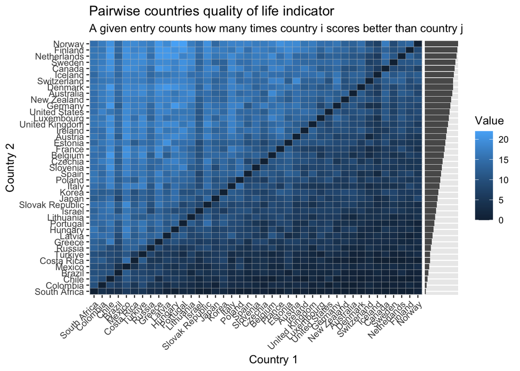

## Questions we would be able to solve

1. Which are the countries with a similar life quality?
2. How many different blocks of countries exists among the one considered?

## Advantages of using this method:

1. We are introducing the block structures in a essentially new type of data. Indeed, classical clusters do not account for hierarchical, assortative and disassortative types of dependency as the Stochastic Blockmodel type of blocks-finding does.
2. We are able to claim a certain type of relation between the blocks, that is, transitivity. This nice mathematical property assures us that the clusters are comparable between them, and the clusters are not indifferent to relabeling